# L1P1 - Primeiro exercício com R e análise

Erick Santana Rodrigues

A seguir, serão analisados os dados sobre o clima (temperatura e chuvas) de Campina Grande e João Pessoa. Primeiro teremos uma visão geral dos dados e então, algumas perguntas serão levantadas e respondidas.

# 1. Visão Geral

```r
climas = read_csv(here::here("data/clima_cg_jp-semanal.csv"), col_types = "cTdddddd")

climas$mes <- as.factor(climas$mes)

head(climas)
```

| cidade | semana | tmedia | tmax | tmin | chuva | mes | ano |
| --- | --- | --- | --- | --- | --- | --- | --- |
| Campina Grande | 1992-12-27 | 26.13333 | 30.4 | 20.7 | 0.0 | 12 | 1992 |
| Campina Grande | 1993-01-03 | 26.11905 | 32.4 | 19.3 | 0.0 | 1 | 1993 |
| Campina Grande | 1993-01-10 | 25.76667 | 32.2 | 19.7 | 0.0 | 1 | 1993 |
| Campina Grande | 1993-01-31 | 25.74000 | 32.0 | 19.9 | 0.4 | 1 | 1993 |
| Campina Grande | 1993-02-07 | 26.31429 | 32.7 | 19.6 | 0.3 | 2 | 1993 |
| Campina Grande | 1993-02-14 | 26.28571 | 32.7 | 20.0 | 0.0 | 2 | 1993 |

Nos nossos dados temos informação a respeito da cidade, semanas, temperaturas (média, mínima e máxima), volume da chuva, mês e ano. Por tanto ao olhar a 2° linha, por exemplo, podemos dizer que em 03/01/1993 Campina Grande teve uma temperatura média de 26 graus e que não houve chuva.

# 2. Perguntas

Nesta seção, serão apresentadas e respondidas 4 perguntas a respeito do clima das cidades. 2 sobre a temperatura e 2 sobre a incidência de chuvas, respectivamente.

#### 2.1 Quais os meses mais quentes e mais frios?

Para responder esta pergunta, iremos considerar a temperatura média como forma de medir quão quente ou frio um mês foi. Isso por que medidas como temperatura máxima ou mínima nos mostram apenas uma temperatura pontual e não representam o cenário completo de tal semana, que apesar de ter registrado uma temperatura bem alta, não foi necessariamente quente.

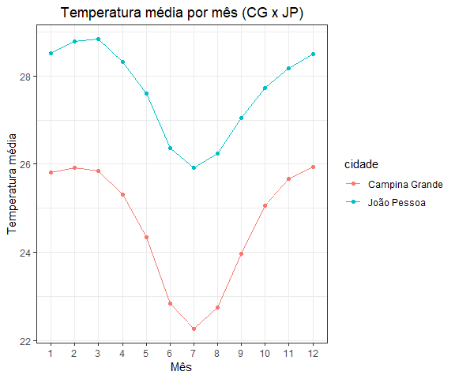

```r
climaPorMes <- climas %>%
    filter(ano != 2019 & ano != 2000) %>%
    group_by(cidade, mes) %>%
    summarise(media = round(mean(tmedia), 2))

ggplot(climaPorMes, aes(x = mes, y = media, group = cidade, color=cidade)) +
        geom_line() +
        geom_point() +
        labs(y = "Temperatura média", x = "Mês") +
        ggtitle("Temperatura média por mês (CG x JP)") +
        theme(plot.title = element_text(hjust = 0.5))
```

Podemos observar que em Campina Grande o mês mais frio foi Julho, com uma temperatura média de pouco mais de 22 graus, enquanto que o mais quente foi dezembro, com uma temperatura bem próxima de 26. Em João Pessoa, o mês mais frio também foi Julho, porém, o mais quente foi Março.

#### 2.2 Qual foi o São João mais frio de Campina Grande?

Para responder esta pergunta, iremos filtrar os dados para ter informações apenas sobre Campina Grande e assim como na primeira questão, utilizaremos a temperatura média como forma de medir quão frio foi um São João.

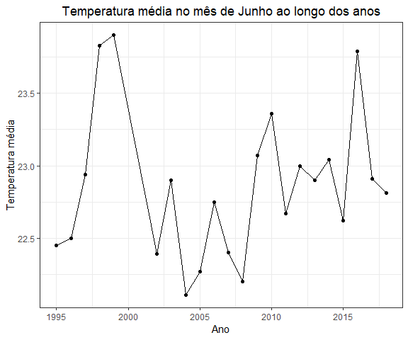

```r
junhoCG <- climas %>%
    group_by(ano) %>%
    filter(mes == 6 & cidade == "Campina Grande") %>%
    summarise(media = round(mean(tmedia), 2))

ggplot(junhoCG, aes(x = ano, y = media, group = 1)) +
        geom_point() +
        geom_line() +
        labs(y = "Temperatura média", x = "Ano") +
        ggtitle("Temperatura média no mês de Junho ao longo dos anos") +
        theme(plot.title = element_text(hjust = 0.5))
```

#### 2.3 A distribuição da chuva é diferente em meses específicos?

Para responder esta pergunta, faremos uso de boxplots para visualizar o espaçamento dos dados e a mediana do volume de chuvas nas duas cidades.

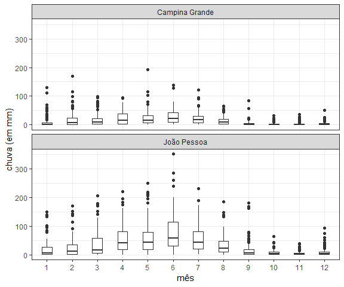

```r
climas %>%
    ggplot(aes(x = mes, y = chuva)) +
    geom_boxplot(width = .4) +
    labs(x = "mês", y = "chuva (em mm)") +
    facet_wrap(~cidade, nrow = 2)
```

Podemos observar que em João Pessoa ocorrem mais chuvas e que tal quantidade vai crescendo até atingir um pico no mês de Junho (onde os dados são mais dispersos) e voltando a diminuir até o final do ano. No caso da Campina Grande ocorrem menos chuvas e tal quantidade tende-se a manter sempre baixa, mesmo com algumas grande chuvas em Fevereiro e Maio. O final do ano é a época em que menos chove na cidade.

#### 2.4 No geral, onde chove mais?

Para responder esta pergunta, iremos calcular a média da quantidade de chuvas por cidade e traçaremos um gráfico de barras para a visualização.

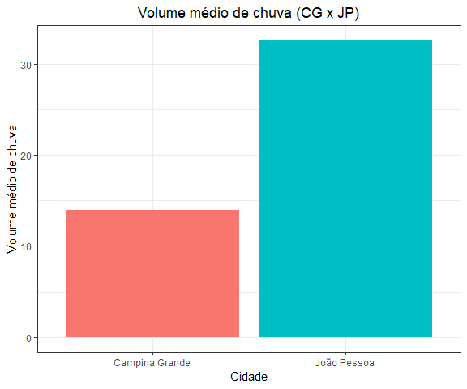

```r
chuvas <- climas %>%
    group_by(cidade) %>%
    summarise(media = round(mean(chuva), 2))

ggplot(chuvas, aes(x=cidade, y=media, fill = cidade)) +
        geom_bar(stat = "identity", show.legend = FALSE) +
        labs(y = "Volume médio de chuva", x = "Cidade") +
        ggtitle("Volume médio de chuva (CG x JP)") +
        theme(plot.title = element_text(hjust = 0.5))
```

Podemos observar que o volume de chuva é maior em João Pessoa e portanto ela é a cidade em que ocorrem mais chuvas.